# Google Data Analytics Capstone Project

# Data Analysis

The section will organize the data by weekdays.

```r
## Order the weekdays in its traditional sequence
trips_v3$day_of_week <- ordered(trips_v3$day_of_week, levels = c("Sunday", "Monday", "Tuesday", "Wednesday", "Thursday", "Friday", "Saturday"))

## Summarize the data based on the type of customer
customer_summary <- trips_v3 %>%
  group_by(member_casual) %>%
  summarize(avg_duration = mean(duration), median_duration = median(duration), max_duration = max(duration), min_duration = min(duration))

## Summarize the data based on the customer type and weekday combinations
weekday_summary <- trips_v3 %>%
  group_by(day_of_week, member_casual) %>%
  summarize(avg_duration = mean(duration), median_duration = median(duration), max_duration = max(duration), min_duration = min(duration))
```

# Results

| Customer Type | Avg Ride Length (seconds) | Med Ride Length (seconds) | Max Ride Length (seconds) | Min Ride Length (seconds) |
| --- | --- | --- | --- | --- |
| Casual | 1974 | 1016 | 3356649 | 0 |
| Member | 811 | 598 | 573467 | 0 |

The results are as follows by casual customers by weekdays

| Weekday | Avg Ride Length (seconds) | Med Ride Length (seconds) | Max Ride Length (seconds) | Min Ride Length (seconds) |
| --- | --- | --- | --- | --- |
| Sunday | 2282 | 1185 | 3235296 | 0 |
| Monday | 1960 | 1016 | 1900899 | 0 |
| Tuesday | 1763 | 902 | 2335375 | 0 |
| Wednesday | 1710 | 881 | 2337785 | 0 |
| Thursday | 1685 | 864 | 2946429 | 0 |
| Friday | 1889 | 949 | 3341501 | 0 |
| Saturday | 2125 | 1135 | 3356649 | 0 |

The results are as follows by member customers by weekdays

| Weekday | Avg Ride Length (seconds) | Med Ride Length (seconds) | Max Ride Length (seconds) | Min Ride Length (seconds) |
| --- | --- | --- | --- | --- |
| Sunday | 923 | 672 | 89995 | 0 |
| Monday | 777 | 572 | 89993 | 0 |
| Tuesday | 764 | 569 | 89996 | 0 |
| Wednesday | 768 | 575 | 573467 | 0 |
| Thursday | 760 | 569 | 89996 | 0 |
| Friday | 796 | 586 | 542972 | 0 |
| Saturday | 905 | 669 | 89996 | 0 |

# Visualization

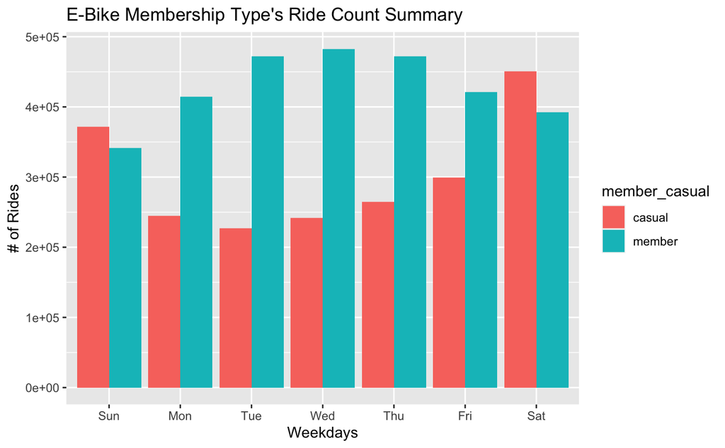

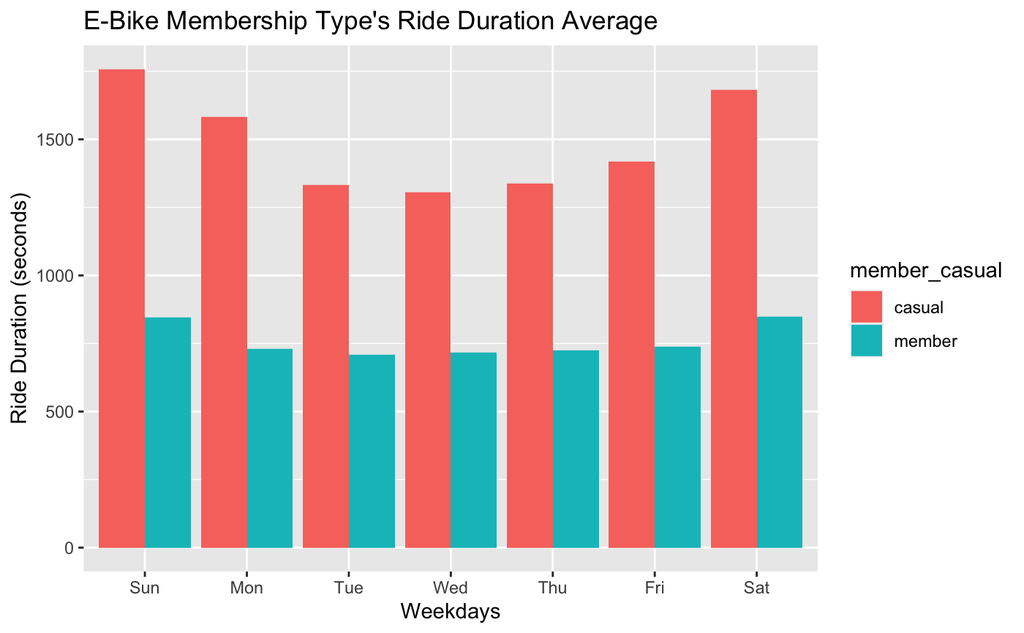

# Conclusion:

Based on the data analysis, I made the following conclusions:

1. Members and casual customers are set apart by their average ride duration such that casual customers ride for a longer time than members.
2. Casual riders tend to ride more on the weekends while members tend to ride during the weekdays.

Thus, after identifying these trends, I recommend the following strategies to convert casual riders to members:

1. Have the cost for weekday riding be cheaper so that the casual riders may consider riding during the weekdays and purchase the annual membership.
2. Make the annual membership not too high of a price so that casual riders may also consider the cost annual membership to get the best deal.